# NASDAQ Composite

Trabajo Final - Modelos de Volatilidad - Financial Statistics

Alexander J Ohrt

17 mars, 2022

# 1 Abstract

MAKE REFERENCES BETWEEN PLOTS (NUMBERS AND CITATIONS IN TEXT, bookdown is necessary maybe?) LATER.

# 2 Introduction

- Scenario and objective of the work. What will be analyzed.
- Precise description of variable (NASDAQ Composite) used in the analysis and description of where the data is gathered from (Yahoo Finance)
- Summary of structure of the work (description of what is done in each part)

The data is gathered directly from Yahoo Finance and can be found [here](https://finance.yahoo.com/quote/%5EIXIC?p=%5EIXIC).

# 3 Empirical Application

## 3.1 Load Data

First, we load the NASDAQ Composite data from Yahoo Finance.

```r
getSymbols("^IXIC",from="2012-01-01", to="2022-03-01", warnings = F)
```

```
#> [1] "^IXIC"
```

```r
dim(IXIC)         # <=== find the size of the data downloaded
```

```
#> [1] 2556    6
```

```r
#write.csv(IXIC, file = "IXIC.csv", row.names = F)
#data <- read.csv2("IXIC.csv")

# Want the adjusted closed data.
ixic <- IXIC[,6]
```

The data does not have any NA values (Weekends and holidays have been removed already), we can start working with the data directly.

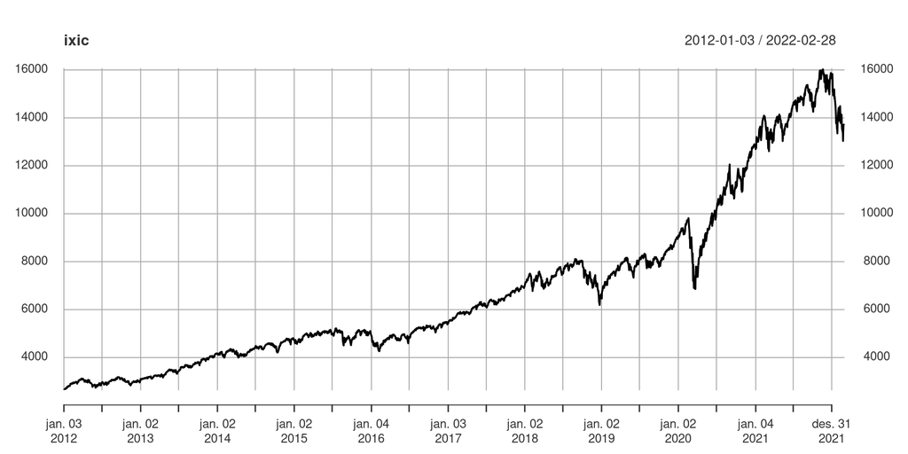

COMMENT: DRAW SOME HAPPENINGS IN THE SERIES (Covid March 2020 and Russia-Ukraine in Feb 2022 + leading up to Feb in the beginning of 2022). Did something happen in Jan 2019 in the US (with tech-companies?) Did something happen in Jan 2016 (small regression).

## 3.2 Analysis of Stationarity

In order to see if the series is stationary, we will employ both informal and formal tests. Immediately, by looking at the plot above (reference later), the series does not look stationary, since the mean of the process looks to change quite dramatically with time. Some more informal tests are done. The function of autocorrelation and partial autocorrelation (empirical) for the series are plotted below.

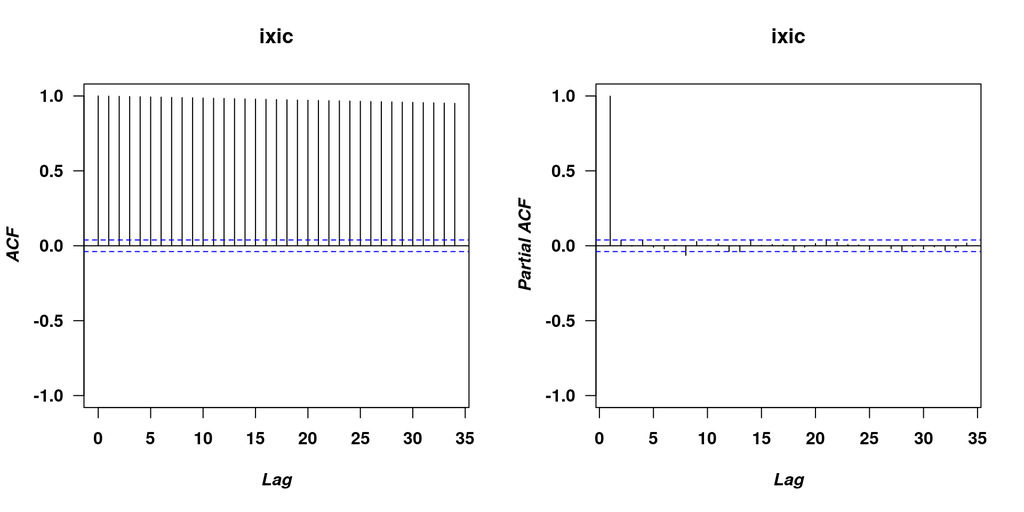

```r
par(mfrow=c(1,2),font=2,font.lab=4,font.axis=2,las=1)
acf(ixic,ylim=c(-1,1),main="ixic")
pacf(ixic,ylim=c(-1,1),main="ixic")
```

As is seen from the function of autocorrelation (ACF), the coefficients decrease slowly. This suggests that the time series is non-stationary, since a stationary series would show exponentially decreasing coefficients in the ACF.

SJEKK AT ALT DETTE GIR MENING (OG BRUKER KORREKTE BEGREPER) SENERE! (TIL SLUTT)

Next, some Ljung-Box tests are done. Here we are testing the joint hypothesis that all $m$ of the correlation coefficients are simultaneously equal to zero. Below we are testing for $m \in \{1, 5, 10, 15, 20\}$.

MAKE A SUMMARY-TABLE HERE INSTEAD LATER! JUST SHOW THE LAGS AND THE P-VALUES.

```r
Box.test(ixic, lag = 1, type = c("Ljung-Box"))
```

```
#>
#>  Box-Ljung test
#>
#> data:  ixic
#> X-squared = 2551.4, df = 1, p-value < 2.2e-16
```

```r
Box.test(ixic, lag = 5, type = c("Ljung-Box"))
```

```
#>
#>  Box-Ljung test
#>
#> data:  ixic
#> X-squared = 12698, df = 5, p-value < 2.2e-16
```

```r
Box.test(ixic, lag = 10, type = c("Ljung-Box"))
```

```
#>
#>  Box-Ljung test
#>
#> data:  ixic
#> X-squared = 25246, df = 10, p-value < 2.2e-16
```

```r
Box.test(ixic, lag = 15, type = c("Ljung-Box"))
```

```
#>
#>  Box-Ljung test
#>
#> data:  ixic
#> X-squared = 37633, df = 15, p-value < 2.2e-16
```

```r
Box.test(ixic, lag = 20, type = c("Ljung-Box"))
```

```
#>
#>  Box-Ljung test
#>
#> data:  ixic
#> X-squared = 49855, df = 20, p-value < 2.2e-16
```

All the $p$-values from the Ljung-Box tests are low, which means that we would reject the null hypothesis that all $m$ correlation coefficients are simultaneously equal to zero. This further suggests that the series is non-stationary.

Next, some formal tests are done to check stationarity of the series. First, the Augmented-Dickey-Fuller (ADF) unit root test is done. The null hypothesis for this case states that the series is integrated of order 1, i.e. that it is non-stationary. Below, the ADF test is done assuming both a stochastic and deterministic trend in the data. The maximum number of lags considered are 20 and the number of lags used are chosen by BIC.

```r
ixic.df<-ur.df(ixic, type = c("trend"), lags=20, selectlags = c("BIC"))
summary(ixic.df)
```

```
#>
#> ###############################################
#> # Augmented Dickey-Fuller Test Unit Root Test #
#> ###############################################
#>
#> Test regression trend
#>
#>
#> Call:
#> lm(formula = z.diff ~ z.lag.1 + 1 + tt + z.diff.lag)
#>
#> Residuals:
#>     Min      1Q  Median      3Q     Max
#> -785.57  -28.42    3.81   35.46  523.61
#>
#> Coefficients:
#>              Estimate Std. Error t value Pr(>|t|)
#> (Intercept)  4.013754   4.319321   0.929  0.35285
#> z.lag.1     -0.002490   0.001457  -1.709  0.08751 .
#> tt           0.013739   0.006845   2.007  0.04482 *
#> z.diff.lag1 -0.090268   0.019879  -4.541 5.87e-06 ***
#> z.diff.lag2  0.051188   0.019870   2.576  0.01005 *
#> z.diff.lag3 -0.004620   0.019903  -0.232  0.81646
#> z.diff.lag4 -0.062694   0.019939  -3.144  0.00168 **
#> z.diff.lag5  0.007115   0.019994   0.356  0.72197
#> z.diff.lag6 -0.026554   0.019982  -1.329  0.18401
#> z.diff.lag7  0.084723   0.020069   4.222 2.51e-05 ***
#> z.diff.lag8 -0.104673   0.020111  -5.205 2.10e-07 ***
#> z.diff.lag9  0.062169   0.020173   3.082  0.00208 **
#> ---
#> Signif. codes:  0 '***' 0.001 '**' 0.01 '*' 0.05 '.' 0.1 ' ' 1
#>
#> Residual standard error: 97.42 on 2523 degrees of freedom
#> Multiple R-squared:  0.05128,    Adjusted R-squared:  0.04715
#> F-statistic:  12.4 on 11 and 2523 DF,  p-value: < 2.2e-16
#>
#>
#> Value of test-statistic is: -1.7093 3.3031 2.0816
#>
#> Critical values for test statistics:
#>       1pct  5pct 10pct
#> tau3 -3.96 -3.41 -3.12
#> phi2  6.09  4.68  4.03
#> phi3  8.27  6.25  5.34
```

From the output it is apparent that BIC chooses 9 lags in the DF test. Moreover, the value of the test-statistic clearly suggests that we cannot reject the null-hypothesis, since the value is much larger than the critical values for this left-sided test. Thus, we would conclude that the series is non-stationary. Note that the test leads to the same conclusion when assuming no trends and when assuming only a drift. Moreover, the same amount of lags are chosen for all three variants. Below, the residuals and the autocorrelation functions of the residuals are plotted, in order to check if the number of lags chosen via BIC is satisfactory.

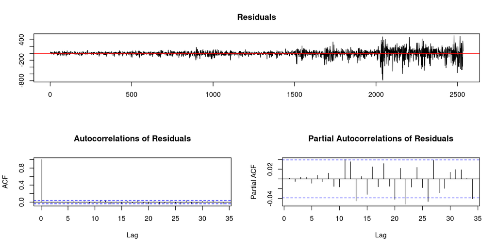

```r
plot(ixic.df)
```

The autocorrelation function of the residuals has no significant coefficients, which leads us to conclude that the amount of lags chosen via BIC is satisfactory.

Next, we check if the returns (rendimientos) are stationary. Below we calculate the returns and remove the first difference, since it is not a numerical value.

```r
rendixic <- diff(log(ixic))
rendixic <- rendixic[-1] # The first difference is NA, needs to be removed.
```

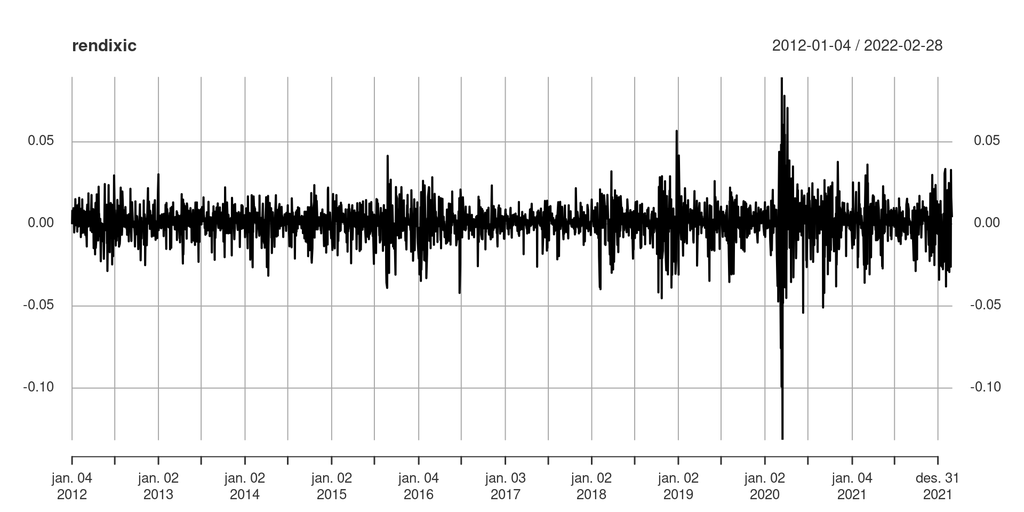

```r
plot(rendixic)
```

Then, the ADF test is calculated without trends, since there does not look to be any trends in the plot of the returns. Note that, as earlier, the conclusion of the test and the amount of lags that are chosen via BIC are the same when assuming a drift or both types of trends.

```r
rendixic.df<-ur.df(rendixic, type = c("none"), lags=20, selectlags = c("BIC"))
summary(rendixic.df)
```

```
#>
#> ###############################################
#> # Augmented Dickey-Fuller Test Unit Root Test #
#> ###############################################
#>
#> Test regression none
#>
#>
#> Call:
#> lm(formula = z.diff ~ z.lag.1 - 1 + z.diff.lag)
#>
#> Residuals:
#>       Min        1Q    Median        3Q       Max
#> -0.107159 -0.004275  0.001424  0.006875  0.067084
#>
#> Coefficients:
#>             Estimate Std. Error t value Pr(>|t|)
#> z.lag.1     -1.07192    0.06437 -16.651  < 2e-16 ***
#> z.diff.lag1 -0.02421    0.06026  -0.402 0.687881
#> z.diff.lag2  0.02301    0.05659   0.407 0.684281
#> z.diff.lag3  0.02650    0.05193   0.510 0.609830
#> z.diff.lag4 -0.02609    0.04723  -0.552 0.580728
#> z.diff.lag5 -0.01914    0.04188  -0.457 0.647707
#> z.diff.lag6 -0.06599    0.03630  -1.818 0.069208 .
#> z.diff.lag7  0.02827    0.02966   0.953 0.340668
#> z.diff.lag8 -0.06861    0.01996  -3.437 0.000597 ***
#> ---
#> Signif. codes:  0 '***' 0.001 '**' 0.01 '*' 0.05 '.' 0.1 ' ' 1
#>
#> Residual standard error: 0.01167 on 2525 degrees of freedom
#> Multiple R-squared:  0.5826, Adjusted R-squared:  0.5811
#> F-statistic: 391.6 on 9 and 2525 DF,  p-value: < 2.2e-16
#>
#>
#> Value of test-statistic is: -16.6512
#>
#> Critical values for test statistics:
#>       1pct  5pct 10pct
#> tau1 -2.58 -1.95 -1.62
```

It is apparent that 8 lags are chosen. Moreover, from the test-statistic above we would reject the null-hypothesis, which means that we have found evidence against the hypothesis that the returns are $I(1)$, i.e. evidence against the hypothesis that the original series is $I(0)$. Thus, we conclude that the returns are $I(0)$ or the original series is $I(1)$. This means that, through the results from this test, the original series is not stationary (which we have seen earlier), but the returns are stationary and can be used further in the analysis. SJEKK AT DET JEG SKRIVER HER STEMMER, TROR DET GJØR DET! HAR NOEN NOTATER FRA ET EKSEMPEL PÅ TAVLA PÅ DETTE!

As earlier, the plot below shows that the amount of lags for the ADF test chosen via BIC is satisfactory.

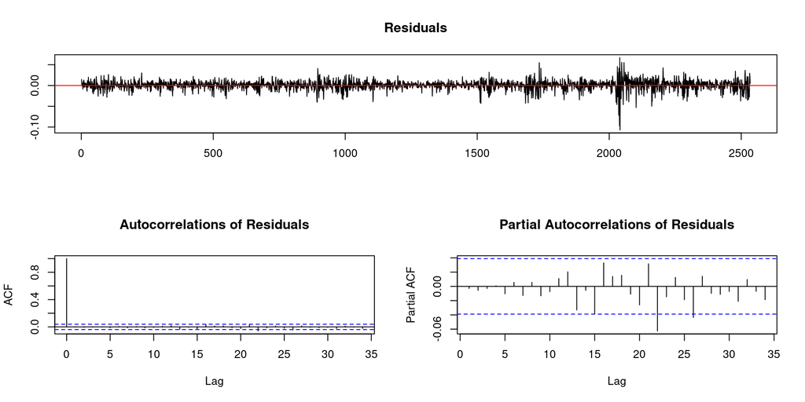

```r
plot(rendixic.df)
```

For completeness, we also use the Philips-Perron (PP) test to check stationarity of the series. This test defines the same null-hypothesis as the ADF test, which means that this is a left-tailed test as well. COULD MAKE A TABLE FROM THESE TWO LAST TESTS (WITH THE MOST IMPORTANT STATISTICS), TO SAVE SOME ROOM IF NEEDED, SINCE THE CONCLUSIONS ARE THE SAME AS EARLIER (AS EXPECTED).

```r
ixic.pp<-ur.pp(ixic, type = c("Z-tau"), model = c("trend"), lags = c("long"))
summary(ixic.pp)
```

```
#>
#> ##################################
#> # Phillips-Perron Unit Root Test #
#> ##################################
#>
#> Test regression with intercept and trend
#>
#>
#> Call:
#> lm(formula = y ~ y.l1 + trend)
#>
#> Residuals:
#>     Min      1Q  Median      3Q     Max
#> -983.02  -26.63    2.68   34.73  658.52
#>
#> Coefficients:
#>              Estimate Std. Error t value Pr(>|t|)
#> (Intercept) 23.065091  10.220234   2.257   0.0241 *
#> y.l1         0.997252   0.001472 677.449   <2e-16 ***
#> trend        0.014404   0.006891   2.090   0.0367 *
#> ---
#> Signif. codes:  0 '***' 0.001 '**' 0.01 '*' 0.05 '.' 0.1 ' ' 1
#>
#> Residual standard error: 99.37 on 2552 degrees of freedom
#> Multiple R-squared:  0.9992, Adjusted R-squared:  0.9992
#> F-statistic: 1.543e+06 on 2 and 2552 DF,  p-value: < 2.2e-16
#>
#>
#> Value of test-statistic, type: Z-tau  is: -1.669
#>
#>            aux. Z statistics
#> Z-tau-mu              2.9272
#> Z-tau-beta            1.9503
#>
#> Critical values for Z statistics:
#>                      1pct      5pct     10pct
#> critical values -3.967077 -3.414184 -3.128848
```

All combinations of trend assumptions and/or long or short lags yield the same conclusions as from the output above; namely that we have not found sufficient evidence to reject the null-hypothesis of non-stationarity of the series. Below the PP-test is done with the returns.

```r
rendixic.pp<-ur.pp(rendixic, type = c("Z-tau"), model = c("constant"), lags = c("short"))
summary(rendixic.pp)
```

```
#>
#> ##################################
#> # Phillips-Perron Unit Root Test #
#> ##################################
#>
#> Test regression with intercept
#>
#>
#> Call:
#> lm(formula = y ~ y.l1)
#>
#> Residuals:
#>       Min        1Q    Median        3Q       Max
#> -0.120202 -0.004652  0.000702  0.006097  0.076985
#>
#> Coefficients:
#>               Estimate Std. Error t value Pr(>|t|)
#> (Intercept)  0.0007315  0.0002344   3.121  0.00182 **
#> y.l1        -0.1345383  0.0196155  -6.859 8.68e-12 ***
#> ---
#> Signif. codes:  0 '***' 0.001 '**' 0.01 '*' 0.05 '.' 0.1 ' ' 1
#>
#> Residual standard error: 0.01183 on 2552 degrees of freedom
#> Multiple R-squared:  0.0181, Adjusted R-squared:  0.01772
#> F-statistic: 47.04 on 1 and 2552 DF,  p-value: 8.683e-12
#>
#>
#> Value of test-statistic, type: Z-tau  is: -57.7836
#>
#>          aux. Z statistics
#> Z-tau-mu            3.1176
#>
#> Critical values for Z statistics:
#>                      1pct      5pct     10pct
#> critical values -3.435853 -2.863173 -2.567664
```

When referring to the returns, the conclusion is the same as for the ADF test; the returns are stationary while the original series is not.

Finally, we use the KPSS test to check stationarity of the series. The null hypothesis for this test states that the series is stationary. In the test below we have chosen to assume the deterministic component as a constant with a linear trend, and we have used short lags. Note that the conclusion is the same with all different variations of assumptions for the test.

```r
ixic.kpss<-ur.kpss(ixic, type = c("tau"), lags = c("short"))
summary(ixic.kpss)
```

```
#>
#> #######################
#> # KPSS Unit Root Test #
#> #######################
#>
#> Test is of type: tau with 8 lags.
#>
#> Value of test-statistic is: 4.8701
#>
#> Critical value for a significance level of:
#>                 10pct  5pct 2.5pct  1pct
#> critical values 0.119 0.146  0.176 0.216
```

Since this is a right-tailed test, the test-statistic is clearly sufficiently large to reject the null-hypothesis to the lowest significance level shown (0.01). Thus, we conclude that the series is non-stationary, as expected. The test below shows that the returns are stationary, in line with what we have concluded earlier, since we cannot find strong evidence against the null-hypothesis.

```r
rendixic.kpss <- ur.kpss(rendixic, type = c("mu"), lags = c("short"))
summary(rendixic.kpss)
```

```
#>
#> #######################
#> # KPSS Unit Root Test #
#> #######################
#>
#> Test is of type: mu with 8 lags.
#>
#> Value of test-statistic is: 0.0313
#>
#> Critical value for a significance level of:
#>                 10pct  5pct 2.5pct  1pct
#> critical values 0.347 0.463  0.574 0.739
```

Conclusively, the original time series is not stationary, but the returns are stationary, which means that the returns will be used in the following analysis. We can be relatively certain that this is the case, since all three formal tests, as well as the informal tests, point to this conclusion.

## 3.3 Basic Statistical Properties of the Stationary Series

Some basic statistical properties of the stationary series, the returns, are shown below.

```r
basicStats(rendixic)
```

```
#>             IXIC.Adjusted
#> nobs          2555.000000
#> NAs              0.000000
#> Minimum         -0.131492
#> Maximum          0.089347
#> 1. Quartile     -0.003980
#> 3. Quartile      0.006759
#> Mean             0.000645
#> Median           0.001093
#> Sum              1.647064
#> SE Mean          0.000236
#> LCL Mean         0.000182
#> UCL Mean         0.001108
#> Variance         0.000142
#> Stdev            0.011933
#> Skewness        -0.841975
#> Kurtosis        12.309021
```

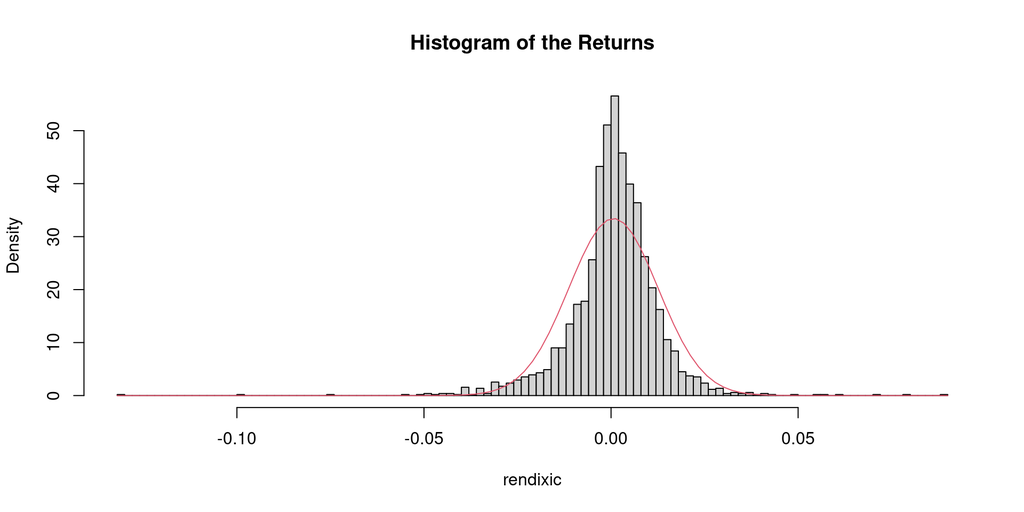

We can see that the series is Leptokurtic, both by the kurtosis value and from the histogram above. The superposed red curve is a Gaussian distribution with empirical mean and standard error according to the returns of the NASDAQ Composite series. Moreover, the skewness is negative, which means that the distribution of the returns are heavy-tailed in the left tail. This is also apparent from the histogram above.

## 3.4 Identification, Estimation and Diagnostics of a Model for the Mean

Plotting the autocorrelation functions of the returns.

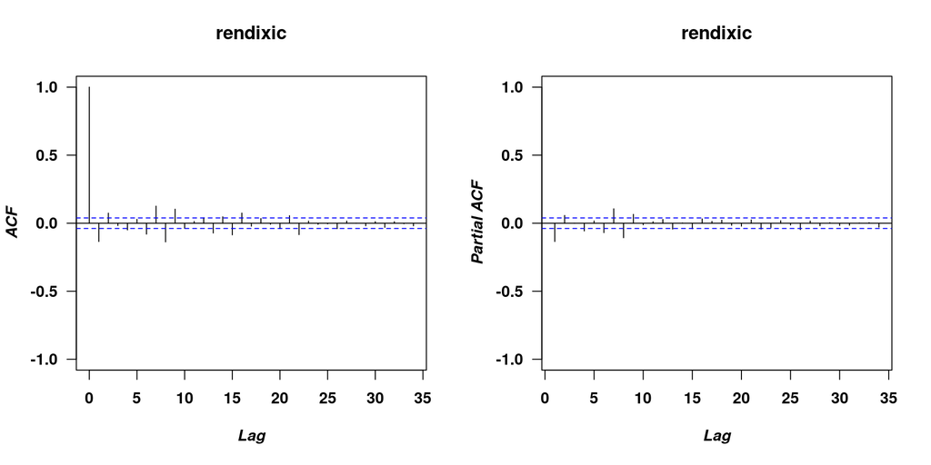

```r
par(mfrow=c(1,2),font=2,font.lab=4,font.axis=2,las=1)
acf(rendixic,ylim=c(-1,1),main="rendixic")
pacf(rendixic,ylim=c(-1,1),main="rendixic")
```

It looks like both the ACF and the partial ACF (PACF) have 9 significant coefficients. This seems like a large order of ARMA-model to estimate, so I will try with smaller models instead. Note that the third coefficient of both ACF and PACF seems to be non-significant, which might be a hint to what order of model would be fitting. The table below shows the BIC and the AIC for different orders of ARMA-models.

Note that all models we have estimated here have significant coefficient estimates to a predetermined significance level of $\alpha = 0.05$.

AIC and BIC of different estimated models for the returns of NASDAQ Composite

[output not shown]

The table above clearly shows that ARMA(2,2) yields the lowest AIC and BIC. Moreover, as noted, the estimated coefficients of the model are significant to a level of $0.05$. The estimated model ARMA(2,2) is shown below

```r
mean.model <- arima(rendixic, order = c(2,0,2),include.mean = TRUE)
mean.model
```

```
#>
#> Call:
#> arima(x = rendixic, order = c(2, 0, 2), include.mean = TRUE)
#>
#> Coefficients:
#>           ar1      ar2     ma1    ma2  intercept
#>       -1.7362  -0.8856  1.6425  0.778      6e-04
#> s.e.   0.0241   0.0226  0.0326  0.030      2e-04
#>
#> sigma^2 estimated as 0.0001349:  log likelihood = 7758.71,  aic = -15505.41
```

```r
pnorm(c(abs(mean.model$coef)/sqrt(diag(mean.model$var.coef))), mean=0, sd=1, lower.tail=FALSE)
```

```
#>           ar1           ar2           ma1           ma2     intercept
#>  0.000000e+00  0.000000e+00  0.000000e+00 7.280516e-149  1.595550e-03
```

Some model diagnostics have to be done to check if the model is adequate. We must check if the model is stationary.

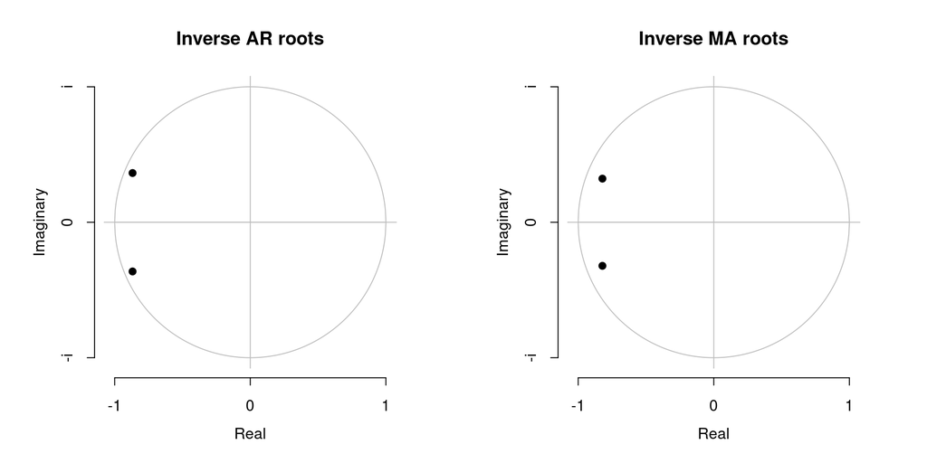

```r
plot(mean.model)
```

The inverse roots of the characteristic polynomial of AR and MA are shows above. DO WE WANT ALL OF THE INVERSE ROOTS TO FALL INSIDE, FOR BOTH THE AR AND THE MA PROCESS? The stationarity condition for the AR-process is satisfied, since the roots have absolute values greater than one. Moreover, the invertibility condition holds for the MA process, since the roots of this process also have absolute values greater than one. Thus, the model is stationary.

The residuals of the model are analyzed below.

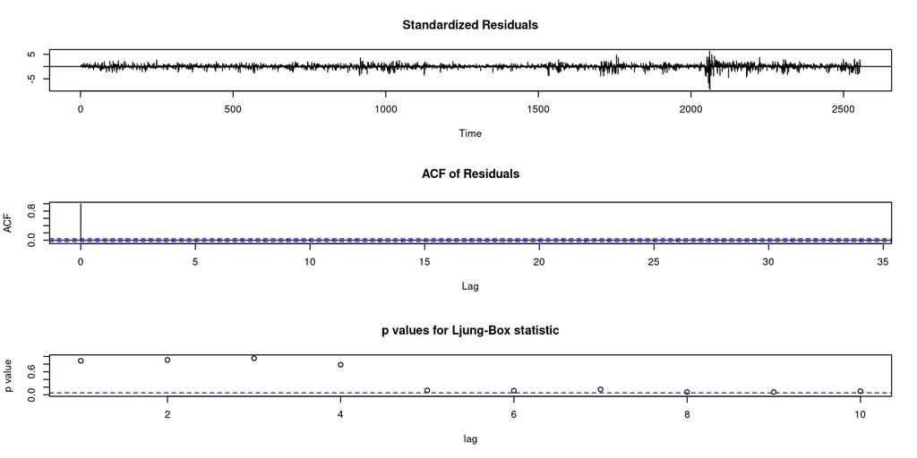

```r
tsdiag(mean.model)
```

Next, a QQ-plot of the residuals, and the residuals themselves (not standardized), is plotted.

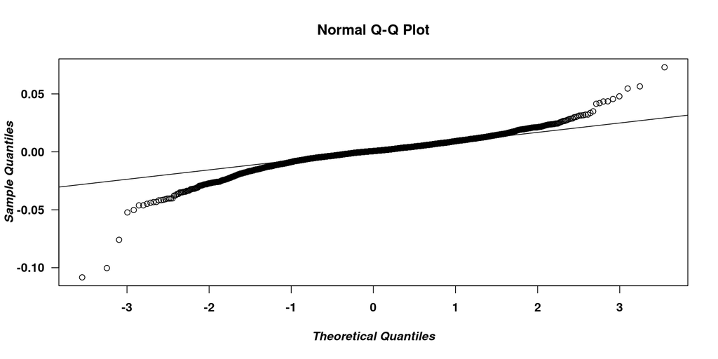

```r
par(mfrow = c(1,1),font=2,font.lab=4,font.axis=2,las=1)
qqnorm(mean.model$residuals)
qqline(mean.model$residuals, datax = FALSE)
```

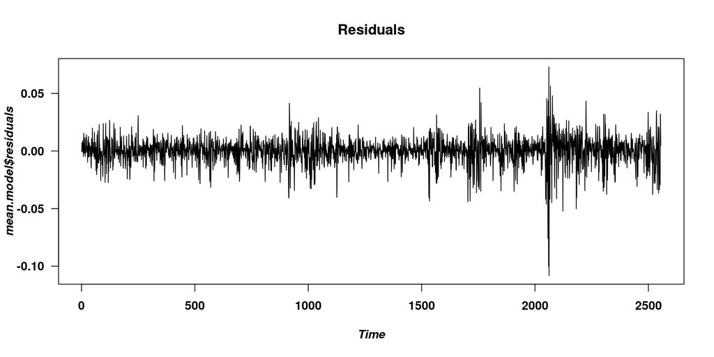

```r
plot(mean.model$residuals)
title (main="Residuals")
```

```r
normalTest(mean.model$residuals,method="jb")
```

```
#>
#> Title:
#>  Jarque - Bera Normalality Test
#>
#> Test Results:
#>   STATISTIC:
#>     X-squared: 7472.6779
#>   P VALUE:
#>     Asymptotic p Value: < 2.2e-16
#>
#> Description:
#>  Thu Mar 17 22:59:46 2022 by user: ajo
```

It is apparent that the residuals have heavy tails. It is not reasonable to assume normality of the residuals, an argument that the Jarque-Bera Normality test further substantiates because its null hypothesis of normality is rejected following the very small p-value.

## 3.5 Identification, Estimation and Diagnostics of a Model for the Variance

First we test for ARCH effects using the residuals of the mean model.

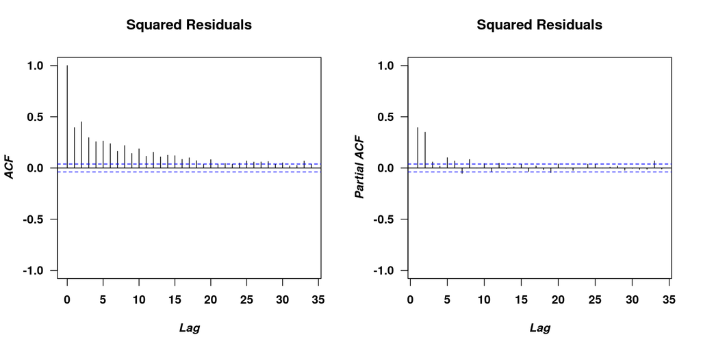

```r
residuals <- mean.model$residuals
residuals2 <- residuals^2

par(mfrow=c(1,2),font=2,font.lab=4,font.axis=2,las=1)
acf(residuals2,ylim=c(-1,1),main="Squared Residuals")
pacf(residuals2,ylim=c(-1,1),main="Squared Residuals")
```

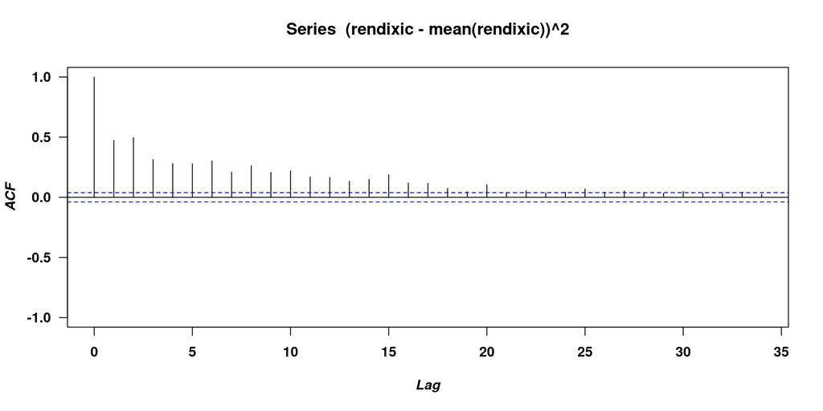

```r
par(mfrow=c(1,1))
# Har acf ovenfor noe sammenheng med plottet nedenfor (se slides 33++ i Volatility Models)?
# For de ser veldig like ut. Men vet ikke helt om residuals^2 fra modellen har noe med dette å gjøre?
# Mulig det er fordi vi estimerer mean vha ARMA-modellen og trekker den fra + kvadrat, noe vi egt gjør direkte fra serien nedenfor!?
acf((rendixic-mean(rendixic))^2, ylim = c(-1,1))
```

```r
Box.test(residuals2,lag=1,type='Ljung')
```

```
#>
#>  Box-Ljung test
#>
#> data:  residuals2
#> X-squared = 397.36, df = 1, p-value < 2.2e-16
```

```r
Box.test(residuals2,lag=5,type='Ljung')
```

```
#>
#>  Box-Ljung test
#>
#> data:  residuals2
#> X-squared = 1487.7, df = 5, p-value < 2.2e-16
```

```r
Box.test(residuals2,lag=15,type='Ljung')
```

```
#>
#>  Box-Ljung test
#>
#> data:  residuals2
#> X-squared = 2163.8, df = 15, p-value < 2.2e-16
```

As seen in the ACF and PACF of the squared residuals, they are clearly presenting autocorrelation, i.e. there are ARCH effects present. This argument is further substantiated by the Ljung-Box tests above, since they lead to the conclusion that the squared residuals are correlated. Thus, it is relevant to identify and estimate a model for the volatility. Joint estimation of the mean and volatility equations, for different types of models, is done in the following.

Now over to estimation of GARCH models for the variance of the returns. First we estimate a ARMA(2,2)-GARCH(1,1) with a t-student distribution. WHY CHOSE A T-STUDENT OVER A NORMAL (OR VICE VERSA)?

```r
spec1 <- ugarchspec(variance.model = list(model = "sGARCH", garchOrder = c(1,1)), mean.model=list(armaOrder=c(2,2)), distribution.model = "std")
(m <- ugarchfit(spec = spec1, data = rendixic))
```

```
#>
#> *---------------------------------*
#> *          GARCH Model Fit        *
#> *---------------------------------*
#>
#> Conditional Variance Dynamics
#> -----------------------------------
#> GARCH Model  : sGARCH(1,1)
#> Mean Model   : ARFIMA(2,0,2)
#> Distribution : std
#>
#> Optimal Parameters
#> ------------------------------------
#>         Estimate  Std. Error  t value Pr(>|t|)
#> mu      0.001230    0.000085  14.4538 0.000000
#> ar1     0.411215    0.010896  37.7392 0.000000
#> ar2     0.468396    0.002407 194.5656 0.000000
#> ma1    -0.467394    0.010241 -45.6404 0.000000
#> ma2    -0.455194    0.009398 -48.4364 0.000000
#> omega   0.000005    0.000002   2.2329 0.025555
#> alpha1  0.163393    0.020408   8.0062 0.000000
#> beta1   0.813486    0.023304  34.9081 0.000000
#> shape   5.240364    0.590405   8.8759 0.000000
#>
#> Robust Standard Errors:
#>         Estimate  Std. Error   t value Pr(>|t|)
#> mu      0.001230    0.000101  12.15400  0.00000
#> ar1     0.411215    0.026259  15.65987  0.00000
#> ar2     0.468396    0.026987  17.35607  0.00000
#> ma1    -0.467394    0.016152 -28.93808  0.00000
#> ma2    -0.455194    0.015014 -30.31821  0.00000
#> omega   0.000005    0.000005   0.95667  0.33873
#> alpha1  0.163393    0.020752   7.87359  0.00000
#> beta1   0.813486    0.039750  20.46509  0.00000
#> shape   5.240364    0.726690   7.21127  0.00000
#>
#> LogLikelihood : 8262.277
#>
#> Information Criteria
#> ------------------------------------
```

[output cut: 52 more lines]

```
#> Negative Sign Bias  0.1143 0.909045
#> Positive Sign Bias  0.9489 0.342756
#> Joint Effect       15.5615 0.001395 ***
#>
#>
#> Adjusted Pearson Goodness-of-Fit Test:
#> ------------------------------------
#>   group statistic p-value(g-1)
#> 1    20     66.58    3.371e-07
#> 2    30     89.80    3.904e-08
#> 3    40     96.76    8.200e-07
#> 4    50    118.17    1.208e-07
#>
#>
#> Elapsed time : 0.6593981
```

```r
m.AIC <- -6.4605
```

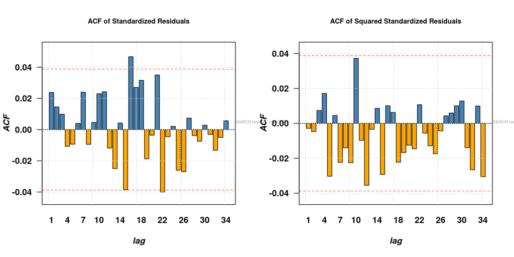

```r
par(mfrow=c(1,2),font=2,font.lab=4,font.axis=2,las=1)
plot(m, which = 10)
plot(m, which = 11)
```

Next we will fit a ARMA(2,2)-GJR-GARCH(1,1) model, assuming a t-distribution.

```r
spec.mgjr <- ugarchspec(variance.model=list(model="gjrGARCH", garchOrder = c(1,1)), mean.model=list(armaOrder=c(2,2)), distribution.model = "std")
(mgjr <- ugarchfit(spec = spec.mgjr, data = rendixic))
```

```
#>
#> *---------------------------------*
#> *          GARCH Model Fit        *
#> *---------------------------------*
#>
#> Conditional Variance Dynamics
#> -----------------------------------
#> GARCH Model  : gjrGARCH(1,1)
#> Mean Model   : ARFIMA(2,0,2)
#> Distribution : std
#>
#> Optimal Parameters
#> ------------------------------------
#>         Estimate  Std. Error   t value Pr(>|t|)
#> mu      0.001047    0.000138  7.606420 0.000000
#> ar1     0.275227    0.319606  0.861146 0.389157
#> ar2     0.470193    0.205718  2.285615 0.022277
#> ma1    -0.320370    0.321325 -0.997029 0.318750
#> ma2    -0.455726    0.214102 -2.128549 0.033292
#> omega   0.000005    0.000000 15.301373 0.000000
#> alpha1  0.000000    0.009195  0.000002 0.999999
#> beta1   0.823974    0.014252 57.815933 0.000000
#> gamma1  0.260477    0.031890  8.168122 0.000000
#> shape   5.594916    0.591457  9.459543 0.000000
#>
#> Robust Standard Errors:
#>         Estimate  Std. Error   t value Pr(>|t|)
#> mu      0.001047    0.000130  8.037487 0.000000
#> ar1     0.275227    0.196628  1.399736 0.161593
#> ar2     0.470193    0.119749  3.926475 0.000086
#> ma1    -0.320370    0.198050 -1.617626 0.105743
#> ma2    -0.455726    0.122730 -3.713240 0.000205
#> omega   0.000005    0.000001  9.596872 0.000000
#> alpha1  0.000000    0.012423  0.000001 0.999999
#> beta1   0.823974    0.013038 63.195840 0.000000
#> gamma1  0.260477    0.035268  7.385755 0.000000
#> shape   5.594916    0.550880 10.156318 0.000000
#>
#> LogLikelihood : 8303.976
#>
```

[output cut: 55 more lines]

```
#> Negative Sign Bias  1.2552 0.2095
#> Positive Sign Bias  0.2208 0.8253
#> Joint Effect        2.7117 0.4383
#>
#>
#> Adjusted Pearson Goodness-of-Fit Test:
#> ------------------------------------
#>   group statistic p-value(g-1)
#> 1    20     70.26    8.326e-08
#> 2    30     85.76    1.611e-07
#> 3    40    109.44    1.324e-08
#> 4    50    129.36    3.569e-09
#>
#>
#> Elapsed time : 1.051875
```

Next, we will fit an ARMA(2,2)-EGARCH model.

```r
spec.egarch <- ugarchspec(variance.model = list(model="eGARCH", garchOrder = c(1,1)), mean.model = list(armaOrder=c(2,2)), distribution.model = "std")
(m.egarch <- ugarchfit(spec = spec.egarch, data = rendixic))
```

```
#>
#> *---------------------------------*
#> *          GARCH Model Fit        *
#> *---------------------------------*
#>
#> Conditional Variance Dynamics
#> -----------------------------------
#> GARCH Model  : eGARCH(1,1)
#> Mean Model   : ARFIMA(2,0,2)
#> Distribution : std
#>
#> Optimal Parameters
#> ------------------------------------
#>         Estimate  Std. Error  t value Pr(>|t|)
#> mu      0.000945    0.000155   6.1066 0.000000
#> ar1     0.137188    0.047974   2.8596 0.004241
#> ar2     0.310470    0.022509  13.7932 0.000000
#> ma1    -0.178777    0.045824  -3.9014 0.000096
#> ma2    -0.292323    0.022317 -13.0986 0.000000
#> omega  -0.389642    0.013992 -27.8483 0.000000
#> alpha1 -0.193182    0.019053 -10.1394 0.000000
#> beta1   0.958980    0.001550 618.8427 0.000000
#> gamma1  0.161978    0.021992   7.3654 0.000000
#> shape   5.708617    0.654727   8.7191 0.000000
#>
#> Robust Standard Errors:
#>         Estimate  Std. Error  t value Pr(>|t|)
#> mu      0.000945    0.000154   6.1427        0
#> ar1     0.137188    0.006823  20.1069        0
#> ar2     0.310470    0.010004  31.0345        0
#> ma1    -0.178777    0.016029 -11.1534        0
#> ma2    -0.292323    0.009662 -30.2545        0
#> omega  -0.389642    0.008250 -47.2320        0
#> alpha1 -0.193182    0.024672  -7.8300        0
#> beta1   0.958980    0.001166 822.5532        0
#> gamma1  0.161978    0.025847   6.2667        0
#> shape   5.708617    0.685084   8.3327        0
#>
#> LogLikelihood : 8308.361
#>
```

[output cut: 55 more lines]

```
#> Negative Sign Bias 0.48021 0.6311
#> Positive Sign Bias 0.06459 0.9485
#> Joint Effect       0.24566 0.9699
#>
#>
#> Adjusted Pearson Goodness-of-Fit Test:
#> ------------------------------------
#>   group statistic p-value(g-1)
#> 1    20     78.12    3.914e-09
#> 2    30     97.88    2.130e-09
#> 3    40    100.98    2.135e-07
#> 4    50    118.33    1.151e-07
#>
#>
#> Elapsed time : 0.6238708
```

```r
m.egarch.AIC <- -6.4958
```

All estimated parameters are significant to a level of $\alpha = 0.05$. For this model, we do not require positivity of the GARCH parameter estimates. WHAT ABOUT STATIONARITY, DO WE REQUIRE THIS? The residual plots below do not show any autocorrelation before moving to a large number of lags, which is a good sign that the model has modelized the data adequately. Moreover, the AIC is smaller for this model compared to the first proposed model. Thus, I would prefer this model over the first model. Note that $\gamma > 0$, which should mean that the positive news have a larger effect on the news compared to the negative news, which does not make sense here, when looking at the news impact curve. THIS IS STRANGE, I DO NOT UNDERSTAND THIS!? ASK PROFE!

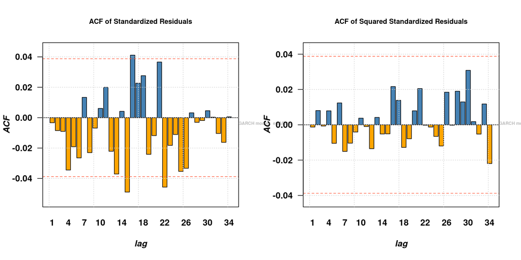

```r
par(mfrow=c(1,2),font=2,font.lab=4,font.axis=2,las=1)
plot(m.egarch, which = 10)
plot(m.egarch, which = 11)
```

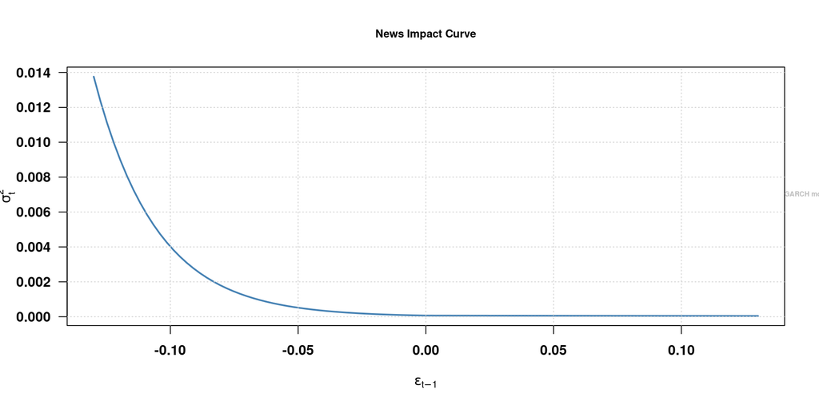

```r
par(mfrow=c(1,1),font=2,font.lab=4,font.axis=2,las=1)
plot(m.egarch, which = 12)
```

Next, we fit and ARMA(2,2)-IGARCH model.

```r
spec.igarch <- ugarchspec(variance.model=list(model="iGARCH", garchOrder = c(1,1)), mean.model=list(armaOrder=c(2,2)), distribution.model = "std")
(m.igarch <- ugarchfit(spec=spec.igarch,data=rendixic))
```

```
#>
#> *---------------------------------*
#> *          GARCH Model Fit        *
#> *---------------------------------*
#>
#> Conditional Variance Dynamics
#> -----------------------------------
#> GARCH Model  : iGARCH(1,1)
#> Mean Model   : ARFIMA(2,0,2)
#> Distribution : std
#>
#> Optimal Parameters
#> ------------------------------------
#>         Estimate  Std. Error  t value Pr(>|t|)
#> mu      0.001238    0.000084  14.7029 0.000000
#> ar1     0.411677    0.010557  38.9943 0.000000
#> ar2     0.467050    0.002286 204.2796 0.000000
#> ma1    -0.468876    0.010466 -44.8003 0.000000
#> ma2    -0.453161    0.009587 -47.2689 0.000000
#> omega   0.000004    0.000002   2.2337 0.025503
#> alpha1  0.181978    0.024164   7.5310 0.000000
#> beta1   0.818022          NA       NA       NA
#> shape   4.750542    0.428166  11.0951 0.000000
#>
#> Robust Standard Errors:
#>         Estimate  Std. Error   t value Pr(>|t|)
#> mu      0.001238    0.000107  11.53516 0.000000
#> ar1     0.411677    0.027459  14.99226 0.000000
#> ar2     0.467050    0.028844  16.19242 0.000000
#> ma1    -0.468876    0.017833 -26.29308 0.000000
#> ma2    -0.453161    0.016554 -27.37489 0.000000
#> omega   0.000004    0.000004   0.94899 0.342627
#> alpha1  0.181978    0.043129   4.21934 0.000025
#> beta1   0.818022          NA        NA       NA
#> shape   4.750542    0.511909   9.28005 0.000000
#>
#> LogLikelihood : 8260.896
#>
#> Information Criteria
#> ------------------------------------
```

[output cut: 51 more lines]

```
#> Negative Sign Bias  0.4695 0.638737
#> Positive Sign Bias  1.2485 0.211975
#> Joint Effect       15.9491 0.001162 ***
#>
#>
#> Adjusted Pearson Goodness-of-Fit Test:
#> ------------------------------------
#>   group statistic p-value(g-1)
#> 1    20     64.44    7.537e-07
#> 2    30     85.41    1.820e-07
#> 3    40     98.48    4.757e-07
#> 4    50    121.14    4.823e-08
#>
#>
#> Elapsed time : 0.5723708
```

```r
m.igarch.AIC <- -6.4602
```

The residuals for the iGARCH look alright, but the AIC is lower for the EGARCH based model.

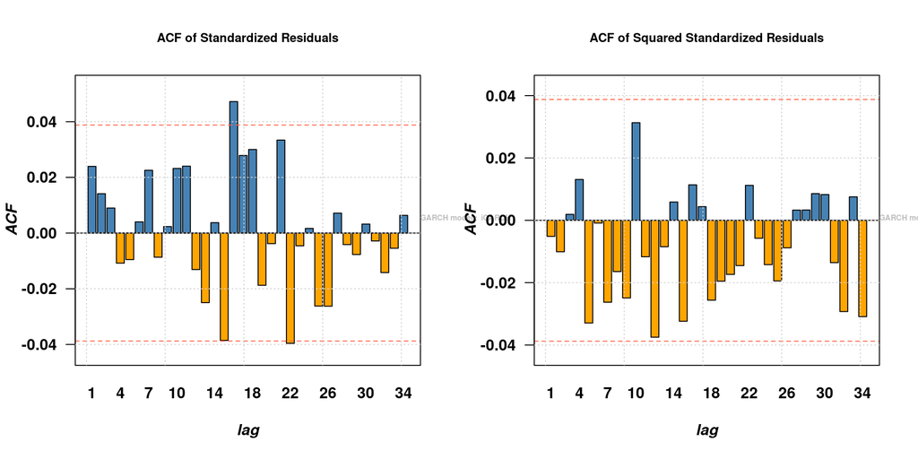

```r
par(mfrow=c(1,2),font=2,font.lab=4,font.axis=2,las=1)
plot(m.igarch, which = 10)
plot(m.igarch, which = 11)
```

# 4 Grafic and Interpretation of the Estimated Series of Volatility

The estimated (anualized) series of volatility for the ARMA(2,2)-EGARCH model is shown below, together with the returns.

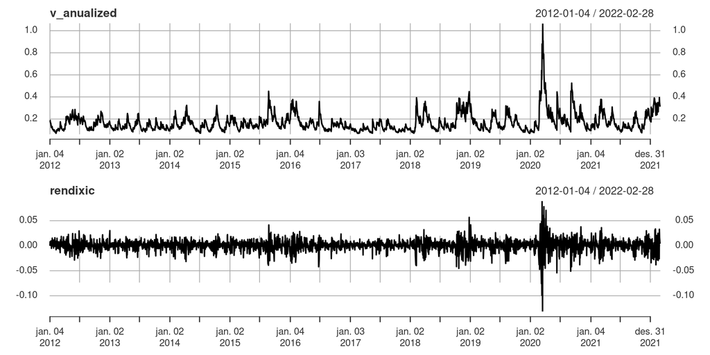

```r
v <- sigma(m.egarch)
v_anualized <- (250)^0.5*v
par(mfcol=c(2,1))  # Show volatility and returns simultaneously.
plot(v_anualized)
plot(rendixic)
```

The general behaviour seems to match relatively well, i.e. the movements in the two plots coincide relatively well. Days with larger (absolute) returns go together with the days with larger estimated volatilities.

A comparison of the estimated volatilities and the absolute value of the returns is given below.

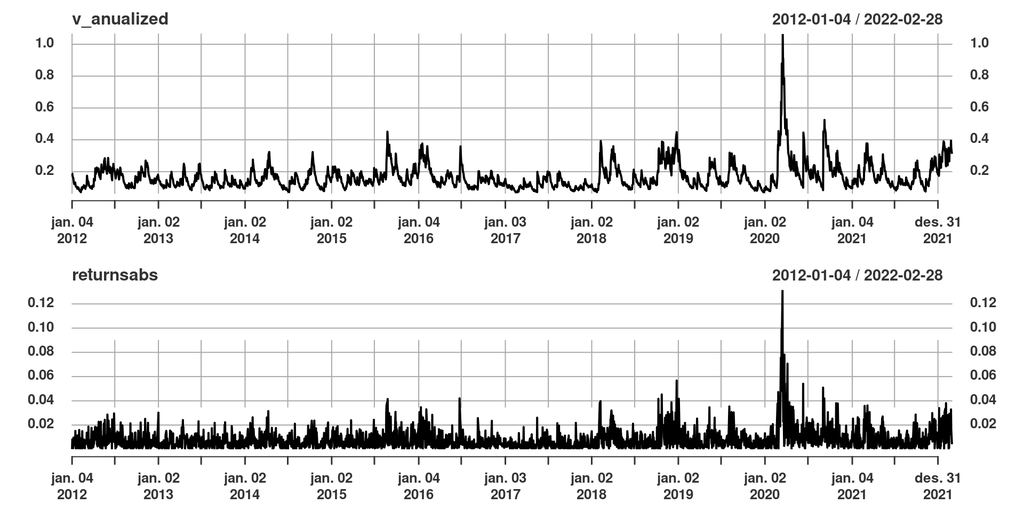

```r
returnsabs <- abs(rendixic)
par(mfrow=c(2,1),font=2,font.lab=4,font.axis=2,las=1)  # Show volatility and returns
plot(v_anualized)
plot(returnsabs)
```

They all seem to follow a similar pattern, which is a good sign, even though we cannot compare the absolute values of the data shown in the plots.

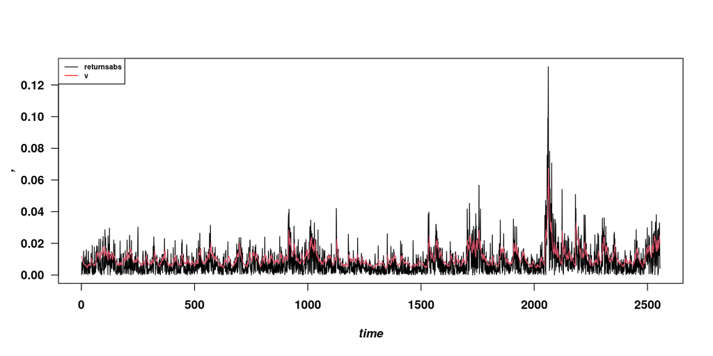

```r
par(mfrow=c(1,1),font=2,font.lab=4,font.axis=2,las=1)
time <-  data.frame(returnsabs, v)
ts.plot(time,gpars= list(xlab="time", ylab=",", col = 1:ncol(time)))
legend("topleft", c("returnsabs","v"), lty=c(1,1), col=c("black","red"), cex=0.6)
```

THESE ARE ALL JUST DIFFERENT WAYS OF SEEING THE SAME RESULTS, REMOVE SOME OF THEM LATER!

# 5 Grafic and Interpretation of the News Impact Curve

The news impact curve for our chosen model is shown below. Since the standard GARCH model does not take the leverage effect into effect, the news impact curve is symmetric.

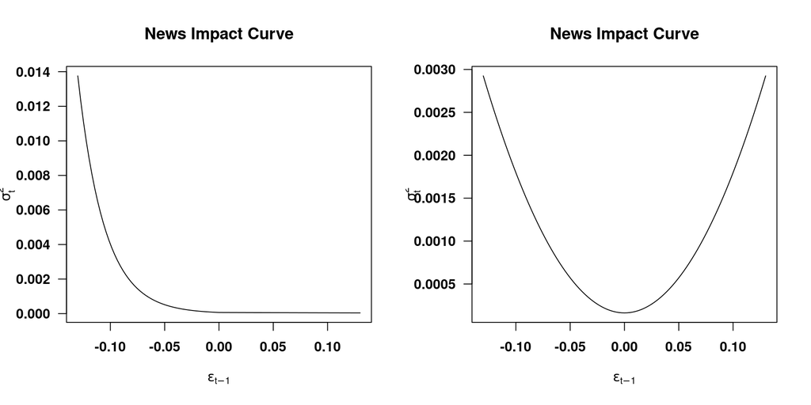

```r
par(mfrow=c(1,2),font=2,font.lab=4,font.axis=2,las=1)
nie <- newsimpact(z = NULL, m.egarch)
plot(nie$zx, nie$zy, ylab=nie$yexpr, xlab=nie$xexpr, type="l", main = "News Impact Curve")
ni <- newsimpact(z = NULL, m)
plot(ni$zx, ni$zy, ylab=ni$yexpr, xlab=ni$xexpr, type="l", main = "News Impact Curve")
```

The EGARCH based model takes the leverage effect into effect, which is the news impact curve is non-symmetric. This curve indicates that the volatility is impacted to a higher degree by negative news compared to the impact on the volatility following positive news, which seems to be increasingly small as the positivity of the news increases THIS IS VERY STRANGE!!

# 6 Volatility Predictions and Interpretations

Below volatility are predicted while leaving out the last 10 observations when estimating the ARMA(2,2)-EGARCH model. The prediction is done 10 steps ahead into the future, first statically.

```r
(m.egarch.pred <- ugarchfit(spec = spec.egarch, data = rendixic, out.sample = 10))
```

```
#>
#> *---------------------------------*
#> *          GARCH Model Fit        *
#> *---------------------------------*
#>
#> Conditional Variance Dynamics
#> -----------------------------------
#> GARCH Model  : eGARCH(1,1)
#> Mean Model   : ARFIMA(2,0,2)
#> Distribution : std
#>
#> Optimal Parameters
#> ------------------------------------
#>         Estimate  Std. Error  t value Pr(>|t|)
#> mu      0.000948    0.000148   6.3869 0.000000
#> ar1     0.155652    0.051076   3.0474 0.002308
#> ar2     0.307442    0.027053  11.3644 0.000000
#> ma1    -0.198667    0.050248  -3.9537 0.000077
#> ma2    -0.286833    0.027142 -10.5680 0.000000
#> omega  -0.391038    0.013548 -28.8640 0.000000
#> alpha1 -0.193163    0.018411 -10.4920 0.000000
#> beta1   0.958837    0.001504 637.3978 0.000000
#> gamma1  0.162456    0.021326   7.6178 0.000000
#> shape   5.672263    0.628296   9.0280 0.000000
#>
#> Robust Standard Errors:
#>         Estimate  Std. Error   t value Pr(>|t|)
#> mu      0.000948    0.000147    6.4711        0
#> ar1     0.155652    0.006593   23.6086        0
#> ar2     0.307442    0.009750   31.5322        0
#> ma1    -0.198667    0.011283  -17.6078        0
#> ma2    -0.286833    0.010276  -27.9119        0
#> omega  -0.391038    0.007671  -50.9775        0
#> alpha1 -0.193163    0.022357   -8.6401        0
#> beta1   0.958837    0.000907 1057.4728        0
#> gamma1  0.162456    0.023734    6.8448        0
#> shape   5.672263    0.663446    8.5497        0
#>
#> LogLikelihood : 8283.935
#>
```

[output cut: 55 more lines]

```
#> Negative Sign Bias 0.43279 0.6652
#> Positive Sign Bias 0.09461 0.9246
#> Joint Effect       0.20103 0.9774
#>
#>
#> Adjusted Pearson Goodness-of-Fit Test:
#> ------------------------------------
#>   group statistic p-value(g-1)
#> 1    20     78.06    3.999e-09
#> 2    30     95.65    4.802e-09
#> 3    40    103.25    1.024e-07
#> 4    50    116.83    1.819e-07
#>
#>
#> Elapsed time : 0.6520989
```

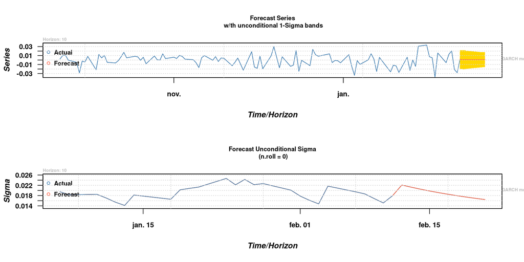

```r
forc <- ugarchforecast(m.egarch.pred, n.ahead=10, n.roll= 0)
#show(forc)
#fpm(forc)

par(mfrow=c(2,1),font=2,font.lab=4,font.axis=2,las=1)
plot(forc, which = 1)
plot(forc, which = 3)
```

```r
uncvariance(m.egarch.pred)^0.5
```

```
#> [1] 0.008652676
```

As we can see from the uppermost plot, these static predictions (for the mean) 10 steps ahead are relatively useless. ALSO LOOKS LIKE THE FORECAST OF THE VARIANCE WILL GO TOWARDS THE UNCONDITIONAL VARIANCE. NOT SURE IN WHAT SITUATIONS THIS SHOULD HAPPEN THOUGH, ASK PROFE PERHAPS!

Next, let us predict 10 steps into the future with a rolling window. We reestimate the model at each time step and estimate one step into the future after each reestimation. After doing this 10 times, we have effectively predicted 10 days into the future.

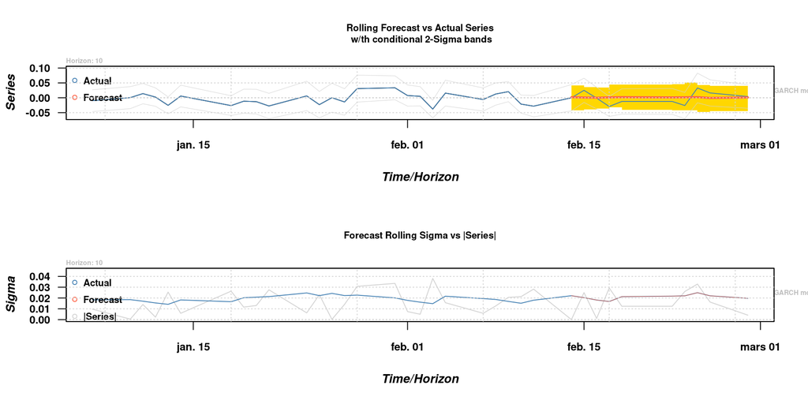

```r
forc2 <- ugarchforecast(m.egarch.pred, n.ahead=1, n.roll= 10)
#fpm(forc2)
#sigma(forc2)
#fitted(forc2)

par(mfrow=c(2,1),font=2,font.lab=4,font.axis=2,las=1)
plot(forc2, which = 2)
plot(forc2, which = 4)
```

The predictions are still lousy, as can be seen from the predictions of the mean in the uppermost plot. However, from the second plot, it looks like the predictions of the variance are somewhat following the same movements as the absolute value of the series; when the absolute value of the series hits a spike, the predictions of the volatility increase as well.

The same type of movement can be seen when predicting with a rolling window 100 steps into the future, where the results of this prediction is shown below.

```r
(m.egarch.pred2 <- ugarchfit(spec = spec.egarch, data = rendixic, out.sample = 100))
```

```
#>
#> *---------------------------------*
#> *          GARCH Model Fit        *
#> *---------------------------------*
#>
#> Conditional Variance Dynamics
#> -----------------------------------
#> GARCH Model  : eGARCH(1,1)
#> Mean Model   : ARFIMA(2,0,2)
#> Distribution : std
#>
#> Optimal Parameters
#> ------------------------------------
#>         Estimate  Std. Error  t value Pr(>|t|)
#> mu      0.000962    0.000160   6.0272 0.000000
#> ar1     0.048676    0.031073   1.5665 0.117230
#> ar2     0.354829    0.052201   6.7973 0.000000
#> ma1    -0.093784    0.034073  -2.7524 0.005916
#> ma2    -0.340675    0.051374  -6.6313 0.000000
#> omega  -0.406135    0.025430 -15.9704 0.000000
#> alpha1 -0.194287    0.015071 -12.8915 0.000000
#> beta1   0.957333    0.003192 299.9545 0.000000
#> gamma1  0.163769    0.044924   3.6455 0.000267
#> shape   5.522329    0.611122   9.0364 0.000000
#>
#> Robust Standard Errors:
#>         Estimate  Std. Error  t value Pr(>|t|)
#> mu      0.000962    0.000168   5.7166 0.000000
#> ar1     0.048676    0.034059   1.4292 0.152949
#> ar2     0.354829    0.032361  10.9648 0.000000
#> ma1    -0.093784    0.024981  -3.7542 0.000174
#> ma2    -0.340675    0.014981 -22.7404 0.000000
#> omega  -0.406135    0.079000  -5.1410 0.000000
#> alpha1 -0.194287    0.057930  -3.3538 0.000797
#> beta1   0.957333    0.009373 102.1392 0.000000
#> gamma1  0.163769    0.124739   1.3129 0.189220
#> shape   5.522329    0.690047   8.0028 0.000000
#>
#> LogLikelihood : 8025.953
#>
```

[output cut: 55 more lines]

```
#> Negative Sign Bias  0.3536 0.7237
#> Positive Sign Bias  0.1932 0.8468
#> Joint Effect        0.1696 0.9823
#>
#>
#> Adjusted Pearson Goodness-of-Fit Test:
#> ------------------------------------
#>   group statistic p-value(g-1)
#> 1    20     76.77    6.652e-09
#> 2    30     90.23    3.350e-08
#> 3    40     96.02    1.033e-06
#> 4    50    112.03    7.687e-07
#>
#>
#> Elapsed time : 0.6709197
```

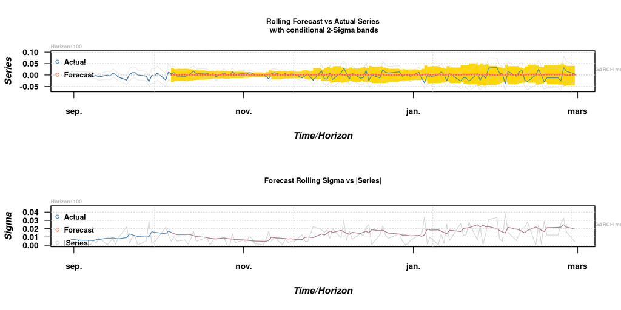

```r
forc3 <- ugarchforecast(m.egarch.pred2, n.ahead=1, n.roll= 100)
#fpm(forc3)
#sigma(forc3)
#fitted(forc3)

par(mfrow=c(2,1),font=2,font.lab=4,font.axis=2,las=1)
plot(forc3, which = 2)
plot(forc3, which = 4)
```

# 7 Calculations via Historical Volatility and EWMA

Historical volatility is calculated below. The historical volatility has been calculated using Simple Moving Average (SMA) over different time periods.

[figure not shown]

```r
par(mfrow=c(1,1),font=2,font.lab=4,font.axis=2,las=1)
Fechas<-as.Date(rownames(zoo(IXIC)))
Fechas<-Fechas[-1] # Eliminate the first date, since it was lost when calculating returns.

vol.hist20 <- SMA(rendixic^2, n=20)
Fechas2<-Fechas[21:2556]
#plot(Fechas2, vol.hist20, type="l", ylab='variance', xlab="time", main='1 month moving average')

vol.hist80 <- SMA(rendixic^2, n=80)
Fechas3<-Fechas[81:2556]
#plot(Fechas3, vol.hist80, type="l", ylab='variance', xlab="time",main='4 month moving average')

vol.hist160 <- SMA(rendixic^2, n=160)
Fechas4<-Fechas[161:2556]
#plot(Fechas4, vol.hist160, type="l", ylab='variance', xlab="time",main='8 month moving average')

vol.hist240 <- SMA(rendixic^2, n=240)
Fechas5<-Fechas[241:2556]
#plot(Fechas5, vol.hist240, type="l", ylab='variance', xlab="time",main='1 year moving average')

par(mfrow=c(2,2), cex=0.6, mar=c(2,2,3,1))
plot(Fechas2, vol.hist20, type="l", ylab='variance', xlab="time", main='1 month moving average')
plot(Fechas3, vol.hist80, type="l", ylab='variance', xlab="time", main='4 month moving average')
plot(Fechas4, vol.hist160, type="l", ylab='variance', xlab="time", main='8 month moving average')
plot(Fechas5, vol.hist240, type="l", ylab='variance', xlab="time", main='1 year moving average')
```

The Exponentially Weighted Moving Average (EWMA) model is used to calculate volatility. Different values of the parameters $k$ and $\lambda$ are used.

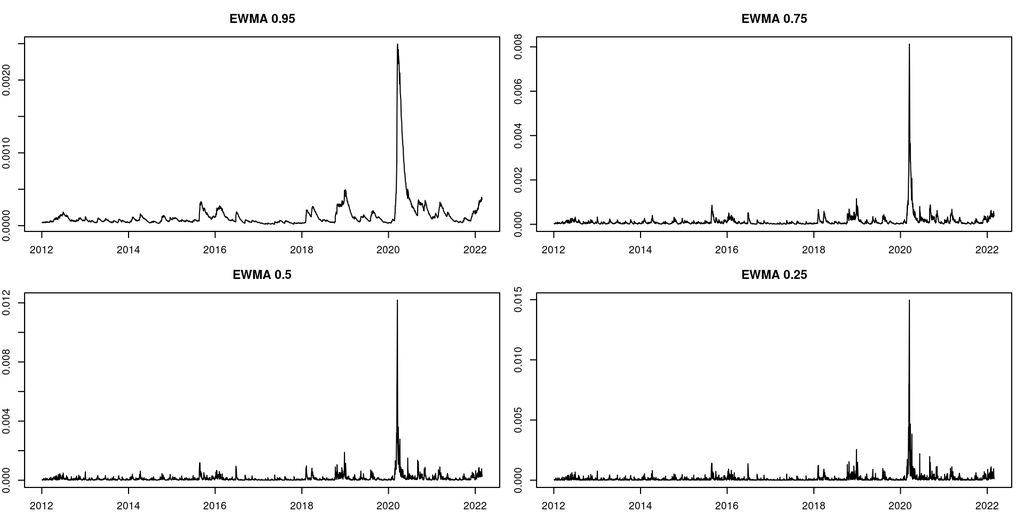

```r
vol.ewma0.95 <- EWMA(rendixic^2, lambda = 0.05) # note: in EWMA lambda is actually 1-lambda
#plot(Fechas, vol.ewma0.95, type="l", ylab='variance', xlab = "time", main='EWMA 0.95')

vol.ewma0.75 <- EWMA(rendixic^2, lambda = 0.25) # note: in EWMA lambda is actually 1-lambda
#plot(Fechas, vol.ewma0.75, type="l", ylab='variance', xlab = "time", main='EWMA 0.75')

vol.ewma0.5 <- EWMA(rendixic^2, lambda = 0.5) # note: in EWMA lambda is actually 1-lambda
#plot(Fechas, vol.ewma0.5, type="l", ylab='variance', xlab = "time", main='EWMA 0.5')

vol.ewma0.25 <- EWMA(rendixic^2, lambda = 0.75) # note: in EWMA lambda is actually 1-lambda
#plot(Fechas, vol.ewma0.25, type="l", ylab='variance', xlab = "time", main='EWMA 0.25')

par(mfrow=c(2,2), cex=0.6, mar=c(2,2,3,1))
plot(Fechas, vol.ewma0.95, type="l", ylab='variance', main='EWMA 0.95')
plot(Fechas, vol.ewma0.75, type="l", ylab='variance', main='EWMA 0.75')
plot(Fechas, vol.ewma0.5, type="l", ylab='variance', main='EWMA 0.5')
plot(Fechas, vol.ewma0.25, type="l", ylab='variance', main='EWMA 0.25')
```

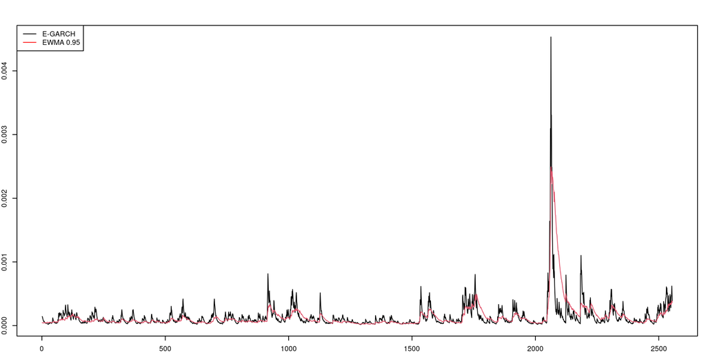

```r
par(mfrow=c(1,1), cex=0.6, mar=c(2,2,3,1))
variance <- v^2
comparison <- data.frame(variance, vol.ewma0.95)
ts.plot(comparison,gpars= list(ylab=",", col = 1:ncol(comparison)))
legend("topleft", c("E-GARCH","EWMA 0.95"), lty=c(1,1), col=c("black","red"))
```

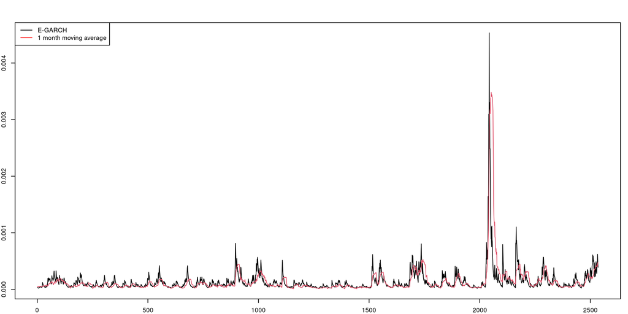

```r
variance2 <- variance[21:2555]
volhist <- vol.hist20[1:2535]
comparison <- data.frame(variance2, volhist)
ts.plot(comparison,gpars= list(ylab=",", col = 1:ncol(comparison)))
legend("topleft", c("E-GARCH","1 month moving average"), lty=c(1,1), col=c("black","red"))
```

NOTE THAT THE TIMES ON THE X-AXIS ARE FUCKED UP. TRY TO FIX THIS LATER!

# 8 Calculation and Interpretation of VaR

```r
# Calculating VaR based on the first type of prediction, without rolling window.
forc <- ugarchforecast(m.egarch, n.ahead=1, n.roll= 0)
show(forc)
```

```
#>
#> *------------------------------------*
#> *       GARCH Model Forecast         *
#> *------------------------------------*
#> Model: eGARCH
#> Horizon: 1
#> Roll Steps: 0
#> Out of Sample: 0
#>
#> 0-roll forecast [T0=2022-02-28]:
#>        Series   Sigma
#> T+1 0.0006739 0.01791
```

```r
var5.garch <- - qnorm(0.95) * 0.01791
show(var5.garch)
```

```
#> [1] -0.02945933
```

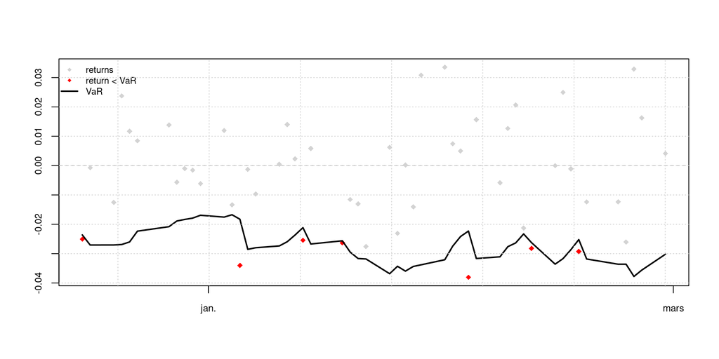

```r
# Calculating VaR based on the second type of prediction, with rolling window.
var.t <-  ugarchroll(spec.egarch, data = rendixic, n.ahead = 1, forecast.length = 50, refit.every = 10,  refit.window = "rolling",
                   calculate.VaR = TRUE, VaR.alpha = 0.05)
plot(var.t, which = 4, VaR.alpha = 0.05)
```

```r
report(var.t, VaR.alpha = 0.05)
```

```
#> VaR Backtest Report
#> ===========================================
#> Model:               eGARCH-std
#> Backtest Length: 50
#> Data:
#>
#> ==========================================
#> alpha:               5%
#> Expected Exceed: 2.5
#> Actual VaR Exceed:   7
#> Actual %:            14%
#>
#> Unconditional Coverage (Kupiec)
#> Null-Hypothesis: Correct Exceedances
#> LR.uc Statistic: 5.855
#> LR.uc Critical:      3.841
#> LR.uc p-value:       0.016
#> Reject Null:     YES
#>
#> Conditional Coverage (Christoffersen)
#> Null-Hypothesis: Correct Exceedances and
#>                  Independence of Failures
#> LR.cc Statistic: 7.839
#> LR.cc Critical:      5.991
#> LR.cc p-value:       0.02
#> Reject Null:     YES
```

```r
#####################################
#comparaci?n in sample ##
##################################
```

# 9 Multivariate DCC

```r
# Get STRS stock data and redo analysis for this stock.
```

# 10 News Impact Surface and Estimated Correlation

# 11 Conclusions